# COVID-19 Model Iteration 3-b-2 Endogeneity Evaluation

The code for the assessment of endogeneity using the Gaussian Copula approach comes from

Hult, G. T. M., J. F. Hair, D. Proksch, M. Sarstedt, A. Pinkwart, & C. M. Ringle (2018). Addressing Endogeneity in International Marketing Applications of Partial Least Squares Structural Equation Modeling. Journal of International Marketing, 26(3), 1–21. https://doi.org/10.1509/jim.17.0151

# Test of non-normality

The Gaussian Copula approach can only be used if the independent variable in question is non-normally distributed.

| Variable | Shapiro-Wilk W | Shapiro Wilk p | Lilliefors D | Lilliefors p |
| --- | --- | --- | --- | --- |
| Distrusting Beliefs | 0.951092151957362 | 7.69572659427866e-11 | 0.0550571418642549 | 0.00292790961434768 |
| Knowledge | 0.94117661511811 | 3.89139708968974e-12 | 0.190551420205387 | 8.90437442297965e-44 |
| Perceived Response Efficacy | 0.893273604911174 | 6.93826344989987e-17 | 0.126518908727434 | 1.49510930430413e-18 |
| Perceived Response Costs | 0.889702635317468 | 3.57796899425672e-17 | 0.147183758902986 | 1.67565647222968e-25 |
| Personal Moral Norm | 0.747072388035255 | 2.65254008691581e-25 | 0.229535798290792 | 1.81209465846421e-64 |
| Descriptive Norm | 0.841136458862543 | 1.53967286672174e-20 | 0.172917057896338 | 9.62042709070001e-36 |

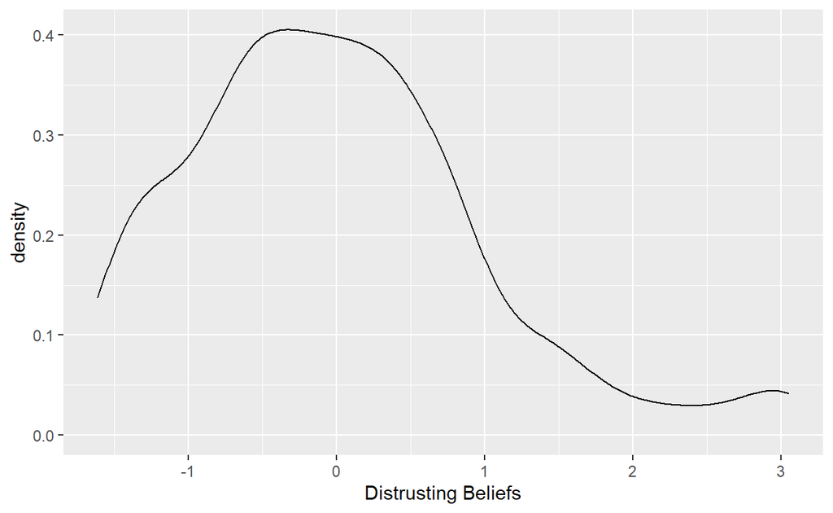

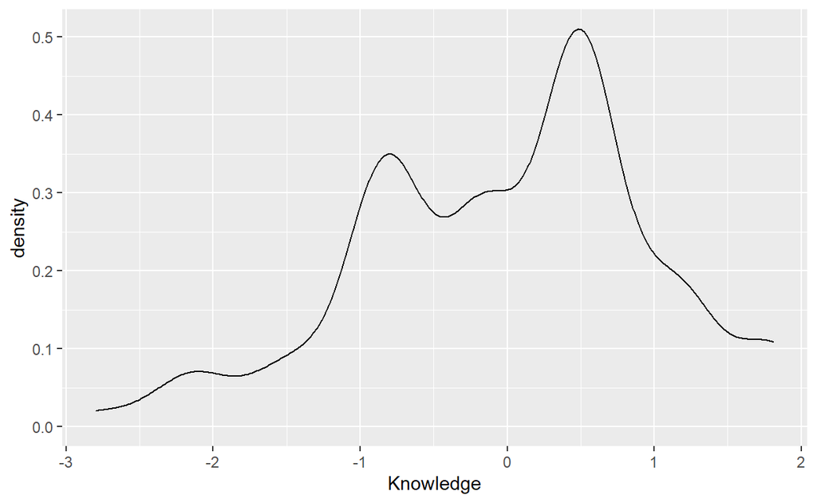

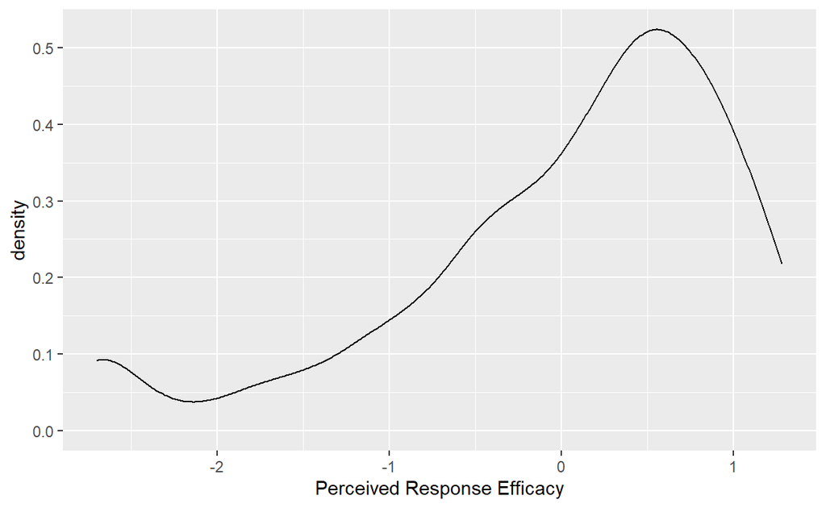

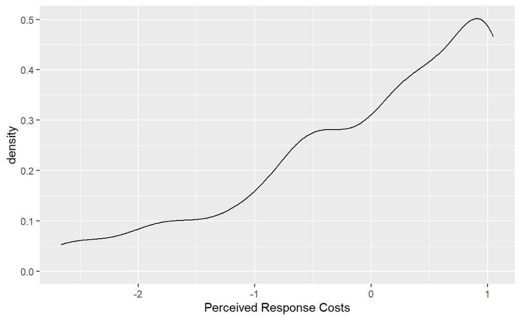

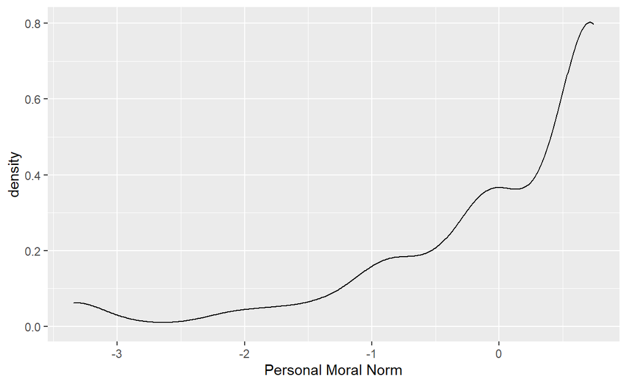

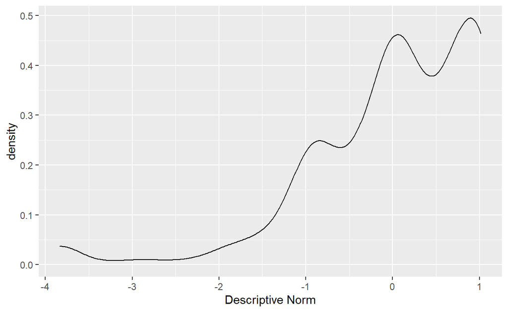

All independent (or endogenous) variables are non-normally distributed. Therefore, the Gaussian Copula approach can be used for all of them.

# Regression of Perceived Response Efficacy Beliefs on Distrusting Beliefs and Knowledge

|  | Distrusting Beliefs | Knowledge | Copula Distrusting Beliefs | Copula Knowledge |
| --- | --- | --- | --- | --- |
| Original model value | -0.61752037187803 | 0.142450508797301 |  |  |
| Original model p | 2.10276186778376e-46 | 0.00017553418728883 |  |  |
| DI copula model value | -0.827008637223738 | 0.139842797605975 | 0.18720999182185 |  |
| DI copula model p | 4.97624538451974e-08 | 0.000227392520122252 | 0.161178873830648 |  |
| KN copula model value | -0.610973095947877 | 0.215386339577432 |  | -0.0530169656994626 |
| KN copula model p | 7.95182733366056e-48 | 0.00188902926672015 |  | 0.172191951776731 |
| DI &amp; KN copula model value | -0.840595436658575 | 0.223876984372192 | 0.206109043992126 | -0.0605021399209199 |
| DI &amp; KN copula model p | 8.4024852773609e-09 | 0.0015127099062943 | 0.105860442900443 | 0.123854977780369 |

Neither the Distrusting Beliefs nor the Knowledge Copula is significant, indicating that there is no endogeneity in the regression of Perceived Response Efficacy on its predictors.

# Regression of Perceived Response Costs Beliefs on Distrusting Beliefs and Knowledge

|  | Distrusting Beliefs | Knowledge | Copula Distrusting Beliefs | Copula Knowledge |
| --- | --- | --- | --- | --- |
| Original model value | -0.595698067677529 | -0.0453752438765503 |  |  |
| Original model p | 1.35234456560386e-30 | 0.269436271315963 |  |  |
| DI copula model value | -0.736908870289363 | -0.047276857562497 | 0.124766778842841 |  |
| DI copula model p | 0.00052120440304458 | 0.23940742821866 | 0.490199513927556 |  |
| KN copula model value | -0.595130497846132 | -0.0382461385084448 |  | -0.00478781538615079 |
| KN copula model p | 1.63264016002062e-31 | 0.598596493690411 |  | 0.914845898163531 |
| DI &amp; KN copula model value | -0.737554500294097 | -0.0345581936989055 | 0.126795681915604 | -0.00812776505871592 |
| DI &amp; KN copula model p | 0.00059406276694377 | 0.654081456739263 | 0.488149272376156 | 0.828522456575673 |

Neither the Distrusting Beliefs nor the Knowledge Copula is significant, indicating that there is no endogeneity in the regression of Perceived Response Costs on its predictors.

# Regression of Behavioral Intention on its predictors

|  | Perceived Response Efficacy | Perceived Response Costs | Personal Moral Norm | Descriptive Norm | Copula Perceived Response Efficacy | Copula Perceived Response Costs | Copula Personal Moral Norm | Copula Descriptive Norm |
| --- | --- | --- | --- | --- | --- | --- | --- | --- |
| Original model value | 0.469977816951011 | 0.112492829952893 | 0.23572230511856 | 0.136481979379115 |  |  |  |  |
| Original model p | 2.56042024003975e-19 | 0.00901386635706227 | 0.000262812136150065 | 0.0152994907969221 |  |  |  |  |
| PRE copula model value | 0.53281706996708 | 0.107522494599832 | 0.224356949540163 | 0.137599299933975 | -0.043745980180428 |  |  |  |
| PRE copula model p | 3.1939167922123e-14 | 0.0120756612688629 | 0.000301049615537849 | 0.0182853540836715 | 0.0955067050311399 |  |  |  |
| PRC copula model value | 0.468841815503553 | 0.136433991282701 | 0.228979442921615 | 0.138412668479002 |  | -0.0117803210311186 |  |  |
| PRC copula model p | 1.37525766605024e-18 | 0.00323996506139286 | 0.00062273163750308 | 0.0140715040123206 |  | 0.401412212895516 |  |  |
| PN copula model value | 0.468663816539983 | 0.113143204397938 | 0.223068931499392 | 0.136793549854648 |  |  | 0.0055864135859388 |  |
| PN copula model p | 1.78120635620264e-20 | 0.0102273192228444 | 0.00513824007287098 | 0.0195931543646722 |  |  | 0.59388801882897 |  |
| DN copula model value | 0.471318562720937 | 0.110063434070345 | 0.226440721665573 | 0.134072764236915 |  |  |  | 0.00537644925135948 |
| DN copula model p | 4.17631630012886e-20 | 0.00907451885524411 | 0.00474820411127601 | 0.0117782617970084 |  |  |  | 0.578164355044802 |

[output cut: 20 more lines]

The copula for Perceived Response Efficacy achieves a significant p-value in some constellations (p < 0.1). Further, adding the single copula increases the Perceived Response Efficacy coefficient by about 0.06. Both of this indicates that Perceived Response Efficacy might be endogenous. There is nothing pointing to endogeneity in any of the other predictors.

The copula will be integrated in the final model to improve the model.